# DATA607 Assignment 5: Working with XML and JSON in R

Albert Gilharry

15 March 2018

## Intro

**For this assignment, we were tasked with creating HTML, XML, and JSON files of 3 or our favourite books on one of our favorite topics.** **At least one of the books must have more than one author.** **Each of the different file structures should be loaded into R data frames. This is a primer for further work with these structures in the semseter.**

## Load Libraries

```r
library("tidyverse")
library("rvest")
library("XML")
library("methods")
library("jsonlite")
library("stringr")
library("DT")
library ("RCurl")
```

## Preview HTML File

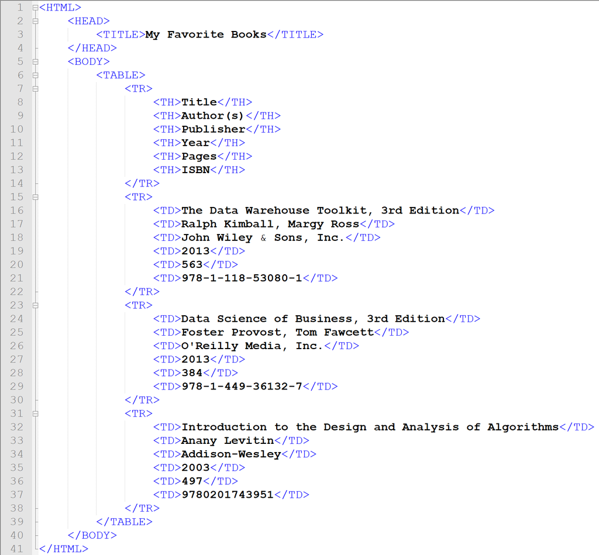

HTML FIle

## Load HTML Data & Create Data Frame

```r
# load HTML data into data frame
url <- "https://raw.githubusercontent.com/albert-gilharry/DATA607-Assignment-5/master/data/books.html"
htmlBooks <- url %>%
  read_html() %>%
  html_nodes("table") %>%
  html_table()

htmlBooks <- htmlBooks[[1]]
```

## View HTML Data Frame

```r
datatable(htmlBooks, options = list(filter = FALSE), filter = "none")
```

|  | Title | Author(s) | Publisher | Year | Pages | ISBN |
| --- | --- | --- | --- | --- | --- | --- |
| 1 | The Data Warehouse Toolkit, 3rd Edition | Ralph Kimball, Margy Ross | John Wiley &amp; Sons, Inc. | 2013 | 563 | 978-1-118-53080-1 |
| 2 | Data Science of Business, 3rd Edition | Foster Provost, Tom Fawcett | O'Reilly Media, Inc. | 2013 | 384 | 978-1-449-36132-7 |
| 3 | Introduction to the Design and Analysis of Algorithms | Anany Levitin | Addison-Wesley | 2003 | 497 | 9780201743951 |

## Preview XML File

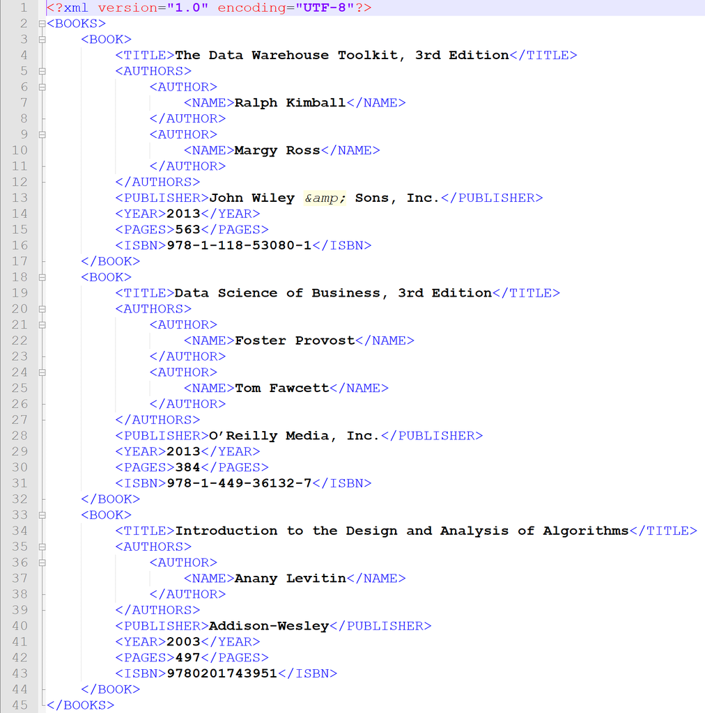

## Load XML Data & Create Data Frame

The books with multiple authors posed a problem because the built in functionality to convert XML to a data frame concatenates the author nodes without a delimiter. For this reason, I looped through the data to format the authors’ names properly. This may not be most efficient way of doing so, but this is a very small data set, so it is fine.

```r
url <- getURL("https://raw.githubusercontent.com/albert-gilharry/DATA607-Assignment-5/master/data/books.xml")
doc <- xmlParse(url)

data <- xpathSApply(doc, "//BOOKS/BOOK/AUTHORS",xmlChildren, simplify = TRUE)
authors = c()
for(i in 1:length(data)){
  c <- c()
  for(j in 1:length(data[[i]])){
   c <-  append( c, xmlValue(data[[i]][[j]]) )
  }
  authors <- append(authors, paste(unlist(c),collapse = ", "))
}

# use the built in function to create the data frame
xmlBooks <- xmlToDataFrame(url,stringsAsFactors = FALSE)

# fix the authors
xmlBooks$AUTHORS <- authors
```

## View XML Data Table

```r
datatable(xmlBooks, options = list(filter = FALSE),filter="none")
```

|  | TITLE | AUTHORS | PUBLISHER | YEAR | PAGES | ISBN |
| --- | --- | --- | --- | --- | --- | --- |
| 1 | The Data Warehouse Toolkit, 3rd Edition | Ralph Kimball, Margy Ross | John Wiley &amp; Sons, Inc. | 2013 | 563 | 978-1-118-53080-1 |
| 2 | Data Science of Business, 3rd Edition | Foster Provost, Tom Fawcett | OReilly Media, Inc. | 2013 | 384 | 978-1-449-36132-7 |
| 3 | Introduction to the Design and Analysis of Algorithms | Anany Levitin | Addison-Wesley | 2003 | 497 | 9780201743951 |

## Preview JSON File

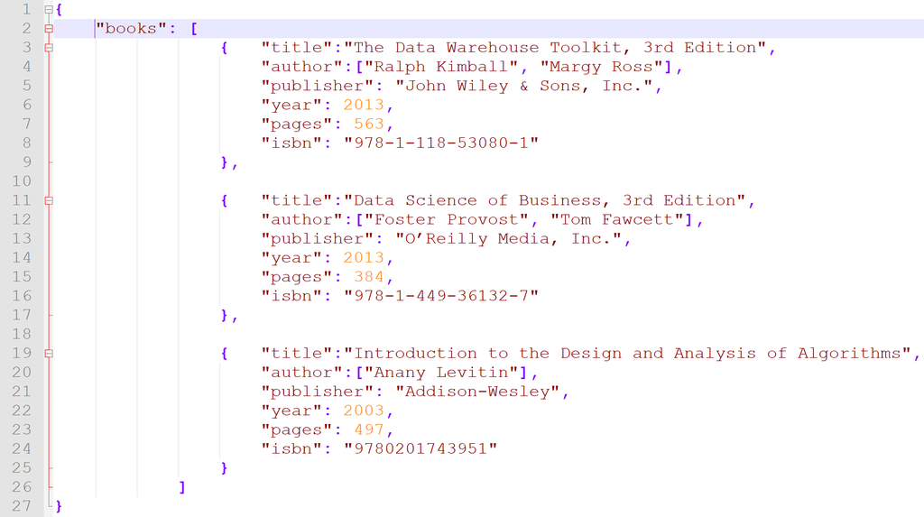

## Load JSON Data & Create Data Frame

The books with multiple authors posed a problem again because the built in functionality to create a data frame from JSON data attaches an list for the authors. I looped through the data to format the authors. This may not be the most efficient way of doing so, but this is a very small data set, so it is fine.

```r
# load JSON data into data frame
url <- getURL("https://raw.githubusercontent.com/albert-gilharry/DATA607-Assignment-5/master/data/books.json")
jsonBooks <- fromJSON(url)
authors = c()
jsonBooks <- jsonBooks$books

# create a comma separated list for authors of each book
for(i in 1:nrow(jsonBooks)){
 authors <- append(authors, paste(unlist( jsonBooks$author[i] ),collapse = ", "))
}

# update authors
jsonBooks$author <- authors
```

## View JSON Data Table

```r
datatable(jsonBooks, options = list(filter = FALSE),filter="none")
```

|  | title | author | publisher | year | pages | isbn |
| --- | --- | --- | --- | --- | --- | --- |
| 1 | The Data Warehouse Toolkit, 3rd Edition | Ralph Kimball, Margy Ross | John Wiley &amp; Sons, Inc. | 2013 | 563 | 978-1-118-53080-1 |
| 2 | Data Science of Business, 3rd Edition | Foster Provost, Tom Fawcett | OReilly Media, Inc. | 2013 | 384 | 978-1-449-36132-7 |
| 3 | Introduction to the Design and Analysis of Algorithms | Anany Levitin | Addison-Wesley | 2003 | 497 | 9780201743951 |